# Accelerated Deep Learning with PyTorch

**Wafa Louhichi**, Michael Isaev, and [Rich Vuduc](https://vuduc.org)

[Jupyter Day Atlanta (2018)](https://atl-jugheads.github.io/jupyter-day-atlanta-ii/).

## **Presentation Outline.**

### 1. Essential PyTorch Background

### 2. PyTorch for Data Analytics

### 3. LeNet Convolutional Neural Network (CNN) in PyTorch

### 4. Application to a Manufacturing Problem

## 1. Essential PyTorch background

- PyTorch is a Python package aimed at accelerating deep learning applications, building on the [Torch](http://torch.ch/) library.
- PyTorch provides a [Numpy](http://www.numpy.org/)-like abstraction for representing *tensors*, or multiway arrays, and it can take advantage of [GPUs](http://www.nvidia.com/object/what-is-gpu-computing.html) for performance.

[figure not shown]

## 1.1 PyTorch Tensors

```python
# Generate a 2-D pytorch tensor (i.e., a matrix)
pytorch_tensor = torch.Tensor(10, 20)
print("type: ", type(pytorch_tensor), " and size: ", pytorch_tensor.shape )
```

```
type:  <class 'torch.FloatTensor'>  and size:  torch.Size([10, 20])
```

```python
# Convert the pytorch tensor to a numpy array:
numpy_tensor = pytorch_tensor.numpy()
print("type: ", type(numpy_tensor), " and size: ", numpy_tensor.shape)

# Convert the numpy array to Pytorch Tensor:
print("type: ", type(torch.Tensor(numpy_tensor)), " and size: ", torch.Tensor(numpy_tensor).shape)
```

```
type:  <class 'numpy.ndarray'>  and size:  (10, 20)
type:  <class 'torch.FloatTensor'>  and size:  torch.Size([10, 20])
```

## 1.2 PyTorch vs. NumPy

#### 1. Tensor creation

```python
t = torch.rand(2, 4, 3, 5)
a = np.random.rand(2, 4, 3, 5)
```

#### 2. Tensor slicing

```python
pytorch_slice = t[0, 1:3, :, 4]
numpy_slice =  a[0, 1:3, :, 4]
```

#### 3. Tensor masking

```python
pytorch_masked = t[t > 0]
numpy_masked = a[a > 0]
```

#### 4. Tensor reshaping

```python
pytorch_reshape = t.view([6, 5, 4])
numpy_reshape = a.reshape([6, 5, 4])
```

## 1.3 PyTorch Variables

- Thin **wrapper** around Tensor in PyTorch
- Helps to build **computation graph**
- Necessary part of **Autograd** - automatic differenciation library
- Keeps gradients with respect to this Variable in **.grad**.

[figure not shown]

## Computation Graph

[figure not shown]

```python
w1 = Variable(torch.randn(5, 4), requires_grad=True)
w2 = Variable(torch.randn(3, 5), requires_grad=True)
```

```python
def model_forward(x):
    return F.sigmoid(w2 @ F.sigmoid(w1 @ x))
```

## 1.4 PyTorch: Backpropagation

**Loss** that describes how far our model from the target

```python
import torch.nn as nn
criterion = nn.MSELoss()
```

**Optimization algorithm** that we use to update the weight update, and

```python
import torch.optim as optim
optimizer = optim.SGD([w1, w2], lr=0.001)
```

**Backpropagation step**

```python
for epoch in range(10):
    loss = criterion(model_forward(x), y)
    optimizer.zero_grad() # Zero-out previous gradients
    loss.backward() # Compute new gradients
    optimizer.step() # Apply these gradients
```

## 1.5 PyTorch CUDA interface

```python
cuda_gpu = torch.cuda.is_available()
if (cuda_gpu):
    print("Great, you have a GPU!")
else:
    print("Life is short -- consider a GPU!")
```

```
Great, you have a GPU!
```

## .cuda()

```python
if cuda_gpu:
    x = x.cuda()
    print(type(x.data))

x = x.cpu()
print(type(x.data))
```

```
<class 'torch.cuda.FloatTensor'>
<class 'torch.FloatTensor'>
```

## 2. PyTorch for Data Analytics

- Build models with **torch.nn** library
- Train models with **torch.autograd** library
- Wrap your data in **torch.utils.data.Dataset** library
- Interface your model and data with your favorite tools using **NumPy interface**

## 2.1 Logistic regression with MNIST

```python
class LogisticRegression(nn.Module):
    def __init__(self, input_size, num_classes):
        super(LogisticRegression, self).__init__()
        self.linear = nn.Linear(input_size, num_classes)

    def forward(self, x):
        x = x.view(x.size()[0], -1)
        return self.linear(x)
```

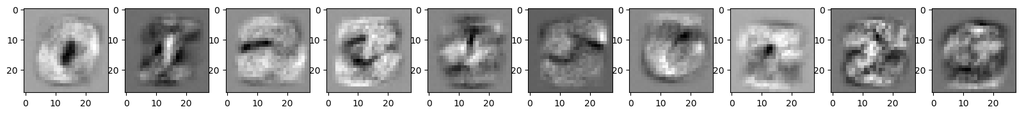

```python
data = model.linear.weight.data.cpu().view(10, 1, 28, 28).numpy()
for col in range(10):
    axes[col].imshow(data[col, 0, :, :], cmap=plt.cm.gray)
plt.show()
```

## 3. LeNet Convolutional Neural Network (CNN) in PyTorch

```python
class LeNet(nn.Module):
    def __init__(self):
        super(LeNet,self).__init__()
        self.conv1 = nn.Conv2d(1,10,kernel_size=5)
        self.conv2 = nn.Conv2d(10,20,kernel_size=5)
        self.conv2_drop = nn.Dropout2d()
        self.fc1 = nn.Linear(320,50)
        self.fc2 = nn.Linear(50,10)

    def forward(self,x):
        x = F.relu(F.max_pool2d(self.conv1(x),2))
        x = F.relu(F.max_pool2d(self.conv2_drop(self.conv2(x)),2))
        x = x.view(-1, 320)
        x = F.relu(self.fc1(x))
        x = F.dropout(x, training=self.training)
        x = self.fc2(x)
        return F.log_softmax(x, dim=1)
```

## 4. Application on surface finish quality inspection

- Surface finish is important to improve appearance as well as quality (rough surfaces wear more quickly).
- The surface roughness is a good predictor of the mechanical interactions and can be due to a non-optimal manufacturing process.
- Roughness is mostly measured using a manual comparison against a surface roughness gage, it's also possible to use a profilometer.
- **Goal:** Automate surface finish quality inspection on aluminum pieces manufactured at Georgia Tech.
- Replicate human judgement of good/bad surface finish => Image classification => CNN

## 4.1 Dataset:

- Training: 490 per class
- Validation: 80 per class
- Testing: 70 per class

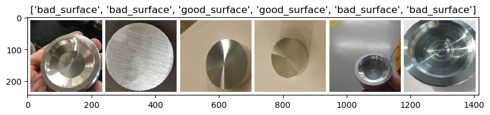

```python
imshow(next(iter(dataloaders['train'])), class_names, num_images=6)
```

## Transfer Learning

Training a deep network from scratch is tricky because of limited dataset and computationally expensive.

**Transfer Learning** is a method of using a deep net pretrained on a larger dataset as feature extractor. We need to change classification layers according to our dataset and retrain the network. For re-training we have two options:

- Finetuning -- retrain all the layers.
- **Fixed feature extractor** -- only retrain classifier (usually, last fully connected layers of the network).

We used **ResNet18** which was trained on ImageNet, we set pretrained=True

```python
model_ft = models.resnet18(pretrained=True)
for param in model.parameters():
    param.requires_grad = False
num_ftrs = model_ft.fc.in_features
model_ft.fc = nn.Linear(num_ftrs, 2)
```

# Training Results:

```python
acc, loss = test(model_ft, 0, criterion, dataloaders['test'])
```

```
Test set: Average loss: 0.1089, Accuracy: 133/140 (95%)
```

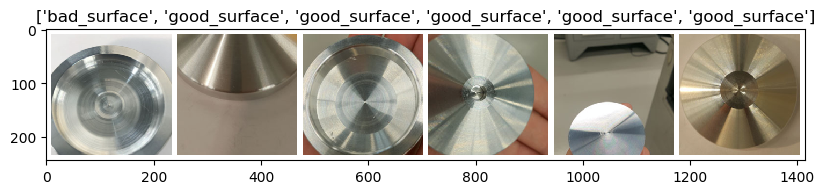

```
Actual labels:
 ['bad_surface', 'good_surface', 'good_surface', 'good_surface', 'good_surface', 'good_surface']
```

```python
visualize_model(model_ft, dataloaders['test'], num_images=6, class_names=class_names)
```

# Future work

1. Adding more variety to dataset
2. Adding more classes for surface quality
3. Propagating class labels back to pixels to to aid visual quality inspection
4. Write an Android application to run surface quality inspection on the phone directly in the machine shop